# Final Project - Blood Lead Levels in NYC Children

Adam Fucich, Asher Andrus, Sophia Baitzel, Anita Avila

03-14-24

## *Hypothesis*

In Boroughs where an increased number of children tested positive for elevated blood lead levels, we anticipate that there will be higher rates of poverty.

## *Background*

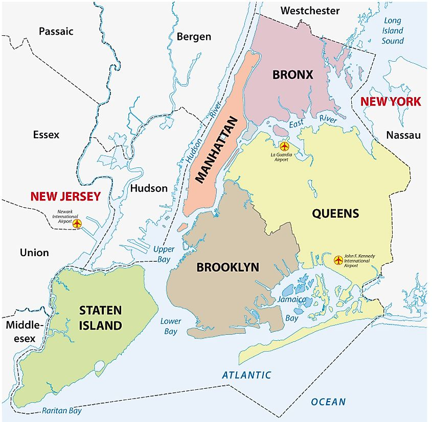

Five NYC Boroughs

## *Methods*

We started by getting rid of variables that were notes, since they were mostly just all NAs. We renamed most variables to be more concise and usable. Then we transformed our variables into numeric and created some new variables:  
1) Total lead poisoned - combined to find how many kids had elevated blood lead levels  
2) Total not lead poisoned, showed how many kids did not have elevated levels  
3) Positive test rate, calculated the total percentage of kids tested who had elevated levels as a percentage.  
We found a second set of data about poverty rates in NYC, but it was located in a couple PDF files, so we input the data into a google sheets document, saved it as a CSV file, and brought it into our repository [^3] [^4].We then joined the two datasets by year and borough name to create a new dataset.

## *Data Tidying*

```r
Filtered_Children_Blood_Lead <- Children_Blood_Lead %>%
  select(-ends_with("_NOTES"))

#Got rid of variables that were notes, were mostly just all NAs

Simple_Children_Blood_Lead <- Filtered_Children_Blood_Lead %>%
  rename(BLL_5 = `Children under 6 years with elevated blood lead levels (BLL) Number BLL >=5 µg/dL`) %>%
  rename(BLL_10 = `Children under 6 years with elevated blood lead levels (BLL) Number BLL>=10 µg/dL`) %>%
  rename(BLL_15 = `Children under 6 years with elevated blood lead levels (BLL) Number BLL>=15 µg/dL`) %>%
  rename(Total_Test = `Children under 6 years with elevated blood lead levels (BLL) Number Tested`) %>%
  rename(BLL_5_ratio = `Children under 6 years with elevated blood lead levels (BLL) Rate  BLL>=5 µg/dL per 1,000 tested`) %>%
  rename(BLL_10_ratio = `Children under 6 years with elevated blood lead levels (BLL) Rate BLL>=10 µg/dL per 1,000 tested`) %>%
  rename(BLL_15_ratio = `Children under 6 years with elevated blood lead levels (BLL) Rate BLL>=15 µg/dL per 1,000 tested`) %>%
  rename(Year = `time_period`)

#Renamed most variables to be more concise and usable

New_Children_Lead_Poision <- Simple_Children_Blood_Lead %>%
  transform(BLL_5 = as.numeric(BLL_5)) %>%
  transform(BLL_10 = as.numeric(BLL_10)) %>%
  transform(BLL_15 = as.numeric(BLL_15)) %>%
  transform(geo_area_id = as.numeric(geo_area_id)) %>%
  transform(borough_id = as.numeric(borough_id)) %>%
  transform(Year = as.numeric(Year)) %>%
  transform(Total_Test = as.numeric(Total_Test)) %>%
  transform(BLL_5_ratio = as.numeric(BLL_5_ratio)) %>%
  transform(BLL_10_ratio = as.numeric(BLL_10_ratio)) %>%
  transform(BLL_15_ratio = as.numeric(BLL_15_ratio))

#Transformed our variables into numerics

New_Blood_Lead_Children <- New_Children_Lead_Poision %>%
  mutate(Total_Lead_Poisoned = (BLL_5 + BLL_10 + BLL_15)) %>%
  mutate(Total_Not_Lead_Poisioned = (Total_Test) - (BLL_5 + BLL_10 + BLL_15))

Poverty_Blood <- right_join(NYC_Poverty, New_Blood_Lead_Children, by = c("Year", "geo_area_name")) %>%
  filter(geo_type == "Borough") %>%
  mutate(Pos_Test_Rate = (Total_Lead_Poisoned/Total_Test) * 100)

#Created new variables:
#1) Total lead poisoned, combining to find how many kids had elevated blood lead levels
#2) Total not lead poisoned, showed how many kids did not have elevated levels
#3) Positive test rate, calculated the total percentage of kids tested who had elevated levels as a percentage.
```

## *Graphs*

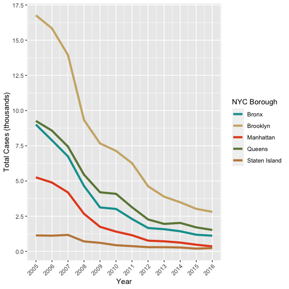

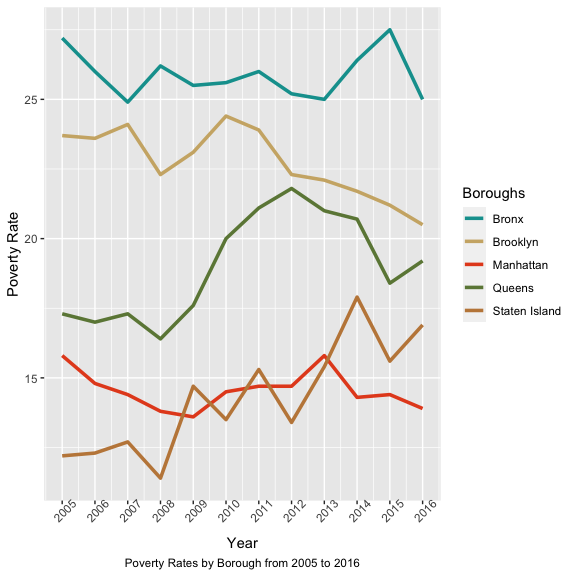

## *Findings*

Comparison between Poverty Rate and Positive Test Rate by Borough

| Borough in 2005 | Poverty Rate | Percent Positive Tests |
| --- | --- | --- |
| Bronx | 27.2 | 13.964341 |
| Brooklyn | 23.7 | 15.696629 |
| Queens | 17.3 | 11.524876 |
| Manhattan | 15.8 | 11.981777 |
| Staten Island | 12.2 | 7.848276 |

| Borough in 2010 | Poverty Rate | Percent Positive Tests |
| --- | --- | --- |
| Bronx | 25.6 | 4.302425 |
| Brooklyn | 24.4 | 6.075745 |
| Queens | 20.0 | 4.434924 |
| Manhattan | 14.5 | 3.117517 |
| Staten Island | 13.5 | 2.773585 |

| Borough in 2015 | Poverty Rate | Percent Positive Tests |
| --- | --- | --- |
| Bronx | 27.5 | 1.923825 |
| Brooklyn | 21.2 | 2.778493 |
| Queens | 18.4 | 1.908380 |
| Staten Island | 15.6 | 1.459854 |
| Manhattan | 14.4 | 1.272000 |

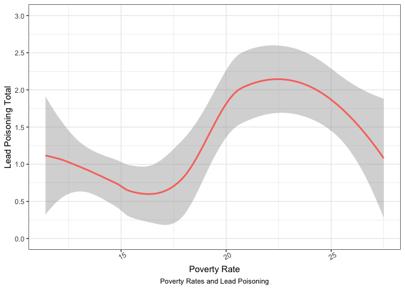

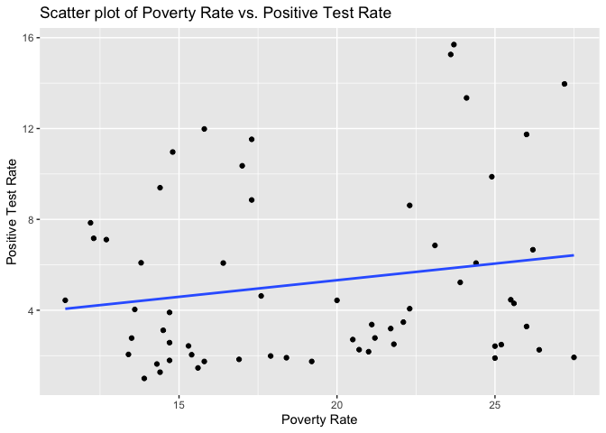

```r
correlation <- cor(Poverty_Blood$Poverty_Rate, Poverty_Blood$Pos_Test_Rate)

#correlation coefficient = .1785725
```

We created a graph showing the correlation between Poverty Rate on the x-axis and Positive test rate on the y-axis, and added a linear regression line to visualize the trend. We also found the correlation coefficient between poverty rate and positive test rate and found there to be a positive coefficient of .1785725, indicating there does appear to be a slight correlation between poverty rate and positive test rate, however it cannot be classified as significant.

# *Discussion*

Our tables show that our hypothesis was not entirely correct, we anticipated that the boroughs with the most rates of poverty would also have the highest rates of elevated Blood Lead Levels in Children. If our hypothesis was correct, the Bronx would have the highest rates of positive tests due to its heightened rate of poverty.

As for our relationship of interest, although we saw a light positive correlation where poverty rates predicted levels of lead poisoning, we didn’t find anything extremely significant linking the two on a small scale. On a larger scale, we did find a relationship, although again, still not very strong.

We might refine our hypothesis by finding another variable that might theoretically fit better to lead poisoning than poverty, or by investigating the directionality of the relationship between poverty and lead poisoning.

# *Conclusion*

The slight relationship between the number of children who tested with elevated lead levels in their blood and the district they live in is important to acknowledge in order to give the city a better idea of who to delegate some more funds to. The cause of elevated lead levels, such as lead piping, or lead paint, would ideally be completely removed as soon as possible, however, the areas that have a higher number of cases also have a higher rate of poverty, meaning that the tenants themselves would not have the funds to be able to remove the paint or put new pipes in the buildings.

A good section of the funding would have to be delivered by the city itself, and being aware of the worst areas would be a good way of knowing where to start. Additionally, the city could also use the data to put in place an initiative to increase free testing for children in areas with higher rates of elevated lead levels, as well as giving free healthcare to those that tested positive.

## *Data Dictionary*

**‘geo_type’**:  
the type of geographic region (borough, citywide, or neighborhood).  
**‘geo_area_id’**:  
each area is given a unique ID number, with boroughs being given numbers 1-5, while neighborhoods are given 3 digit numbers, with their first number being correlated with the ID of the borough they are in.  
**‘geo_area_name’**:  
the name of the borough, city, or neighborhood respectively. **‘borough_id’**:  
the same as the ID number given to the boroughs in geo_area_id. This column gives every neighborhood the ID of the borough its located in.  
**‘Year’**:  
the year that the test data in the row is from. The years range from 2005-2016.  
**‘Poverty_Rate’**:  
The poverty rate of the borough in the given year.  
**‘BLL_5’**:  
the number of children in that year that tested as having a Blood Lead Level of equal to or over 5 micrograms per deciliter.  
**‘BLL_10’**:  
the number of children in that year that tested as having a Blood Lead Level of equal to or over 10 micrograms per deciliter.  
**‘BLL_15’**:  
the number of children in that year that tested as having a Blood Lead Level of equal to or over 15 micrograms per deciliter.  
**‘Total_Test’**:  
the total number of children that were tested in that area and that year.  
**‘BLL_5_ratio’**:  
the ratio describing the number of children that tested with a Blood Lead Level of equal to or over 5 micrograms per deciliter over total children tested that year.  
**‘BLL_10_ratio’**:  
the ratio describing the number of children that tested with a Blood Lead Level of equal to or over 10 micrograms per deciliter over total children tested that year.  
**‘BLL_15_ratio’**:  
the ratio describing the number of children that tested with a Blood Lead Level of equal to or over 15 micrograms per deciliter over total children tested that year.  
**‘Total_Lead_Poisoned’**:  
the combined number of children who tested positive for elevated blood lead levels. BLL_5 + BLL_10 + BLL_15 = Total_Lead_Poisoned.  
**‘Total_Not_Lead_Poisoned’**:  
the combined number of children who tested negative for elevated blood lead levels. Total_Test – Total_Lead_Poisoned = Total_Not_Lead_Poisoned.  
**‘Pos_Test_Rate’**:  
the percentage of children that tested positive out of the total number of children tested.

[^1]: “Centers for Disease Control and Prevention,” Centers for Disease Control and Prevention, 2 Sept. 2022, www.cdc.gov/nceh/lead/prevention/health-effects.htm.
[^2]: “Lead Poisoning.” Lead Poisoning Prevention - NYC Health, www.nyc.gov/site/doh/health/health-topics/lead-poisoning-prevention.page. Accessed 13 Mar. 2024.
[^3]: “The CEO Poverty Measure, 2005 - 2011,” NYC Center for Economic Opportunity, April 2013, https://www.nyc.gov/assets/opportunity/pdf/13_poverty_measure_report.pdf
[^4]: “New York City Government Poverty Measure 2005–2016” Mayor’s Office of Operations, The City of New York, April 2018, https://www.nyc.gov/assets/opportunity/pdf/18_poverty_measure_report.pdf